**CSE2215** - Computer Graphics

Elmar Eisemann, Ricardo Marroqium, Mathijs Molenaar

# Transformations

In this weeks assignment we will look at using matrices to describe, combine and apply transformations. The assignment consists of two separate exercises: a robot arm and a solar system. Both exercises require you to apply rotation, scale and translation operations in the correct order to achieve the desired effect.

## OpenGL Math Library

Unlike previous week you do not have to implement the linear algebra constructs yourself. Instead we will use the [glm](https://glm.g-truc.net/0.9.9/index.html) library. This library btoh 2D, 3D and 4D vectors and matrices as well as many operations that can be applied to these types.

We can create a 2D/3D/4D `glm` vector in various ways:

```cpp
glm::vec3 myFirstVec3 { 1, 2, 3 }; // Creates a vector (1, 2, 3)
glm::vec3 singleValueVec3 { 5 }; // Creates a vector (5, 5, 5)

glm::vec2 multiValueVec2 { 1, 2 }; // Creates a vector (1, 2)
glm::vec3 multiValueVec3 { myFirstVec2, 3 }; // Creates a vector (1, 2, 3)
glm::vec4 multiValueVec4 { multiValueVec3, 4 }; // Creates a vector (1, 2, 3, 4)
```

Unlike our simple vector class that we implemented in the first assignment, glm supports operator overloading. Operator overloading is a powerfull feature in `c++` which allows us (or in this case, `glm`) to define the behavior of the `+`, `-`, `*` and `/` operands for a custom class. In practice, this means that math heavy code is greatly simplified.

```cpp
glm::vec3 a { 2, 5, 3 };
glm::vec3 b { 9, -3, -1 };
glm::vec3 c = a + b; // (11, 2, 2)
```

The `glm` library also provides helper functions to create transformations such as rotation, translation and scale. These functions take an existing matrix, compute the desired transformation matrix and multiply it by the existing matrix. The multiplication order is such that the transform operation is performed *before* the transformation stored in the input matrix.

```cpp
// Create an identity matrix (1 on the diagonal, 0 everywhere else).
glm::mat4 identity = glm::identity<glm::mat4>();

float angle = glm::radians(45.0f); // Convert angle from degrees to radians.
glm::vec3 axis { 0, 1, 0 }; // Positive y-axis
glm::mat4 rotation = glm::rotate(identity, angle, axis);

// Translate by (1, 2, 3) *then* rotate by 45 degrees around the positive y-axis.
glm::mat4 translateThenRotate = glm::translate(rotation, glm::vec3(1, 2, 3));

// Scale by (1, 2, 3) *then* rotate by 45 degrees around the positive y-axis.
glm::mat4 scaleThenRotate = glm::scale(rotation, glm::vec3(1, 2, 3));

// Multiply the vector (0, 1, 2, 1) in homogenous coordinates by the matrix.
glm::vec4 resultHomogeneous = scaleThenRotate * glm::vec4(0, 1, 2, 1);
// Convert from homogenous coordinates to cartesian coordinates.
// Casting a vec4 to a vec3 throws away the last coordinate (w).
glm::vec3 result = glm::vec3(resultHomogeneous) / resultHomogeneous.w;
```

Additionally, we provide some helper functions which compute the rotation / translation / scale matrices directly. Using these functions is **optional** but it allow you to write matrix multiplications from right to left (which is common in literature).

```cpp
glm::mat4 rotationMatrix(float angle, const glm::vec3& axis);
glm::mat4 translationMatrix(const glm::vec3& translation);
glm::mat4 scaleMatrix(const glm::vec3& scale);

float angle = glm::radians(45.0f); // Convert angle from degrees to radians.
glm::vec3 axis { 0, 1, 0 }; // Positive y-axis
glm::mat4 translateThenRotate = rotationMatrix(angle, axis) * translationMatrix(glm::vec3(1, 2, 3));
```

You can find the full `glm` manual [here](https://github.com/g-truc/glm/blob/0.9.9.2/doc/manual.pdf).

## 1. Solar System

For this first exercise we will “simulate” our solar system. For the sake of simplicity we will only consider rotations around a single axis (the positive y-axis `glm::vec3(0, 1, 0)`). A solar system consists of various *celestrial bodies* which orbits around one another. The one exception to that is the sun which is at the origin of our solar system (`glm::vec3(0)`). Apart from orbiting, a celestrial body also spins around it’s own axis. Finally, each body may have a different size (e.g. moon is smaller than the earth).

Each celestrial body is represented by the following struct:

```cpp
struct CelestrialBody {
    float radius { 1.0f }; // Radius of the sphere that represents the body.
    float spinPeriod { 0.0f }; // Time it takes to complete one spin rotation.

    // If pOrbitAround is nullptr then this body is at the origin (e.g. the sun).
    CelestrialBody* pOrbitAround { nullptr }; // The body that this body is orbiting around.
    float orbitAltitude { 0.0f }; // Orbit altitude (as measured from center of bodies).
    float orbitPeriod { 0.0f }; // Time it takes to complete a full orbit rotation.

    // ONLY REQUIRED FOR UI - DON'T TOUCH THIS.
    std::string name;
    GLuint texture;
};
```

When you start the application it should look something like this:

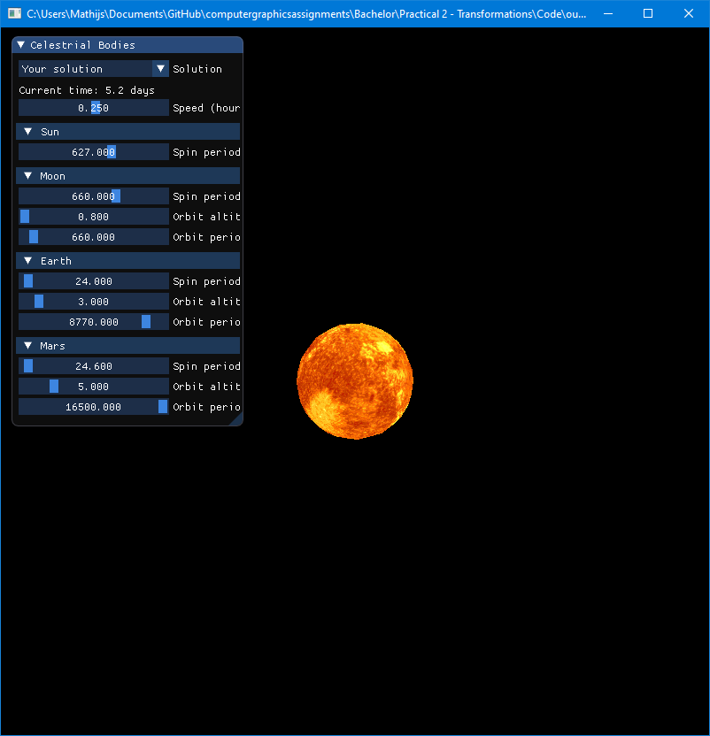

Each body is rendered as a sphere centered at the origin with radius=1. The dummy implementation that we provide uses an identity matrix for each celestrial body, hence they are all drawn at the origin with the same radius.

Your goal is to implement the following function in `solar_system/src/solar_system.cpp`. It should return for each celestrial body a matrix that describes the transformation at the given time. This transformation matrix should rotate / translate / scale the input sphere (center=origin, radius=1) according to the CelestrialBody struct.

```cpp
std::vector<glm::mat4> computeCelestrialBodyTransformations(
    gsl::span<const CelestrialBody> celestrialBodies, float time);
```

Both the orbit and spin should use the positive y-axis (`glm::vec3(0, 1, 0)`) as the axis of rotation. Keep in mind that the orbit and spin are described using a period. This is the amount of time it takes for the body to complete a full rotation (`2.0f * glm::pi<float>()`). Orbiting should not create any spin on it’s own. That is, if we disable spin then while the object is orbiting it should not change in orientation. Finally, the orbit altitude describes the distance between the centers of the two bodies. At `time=0.0f` each body should be to the right (positive X-axis) of the celestrial body that it is orbiting.

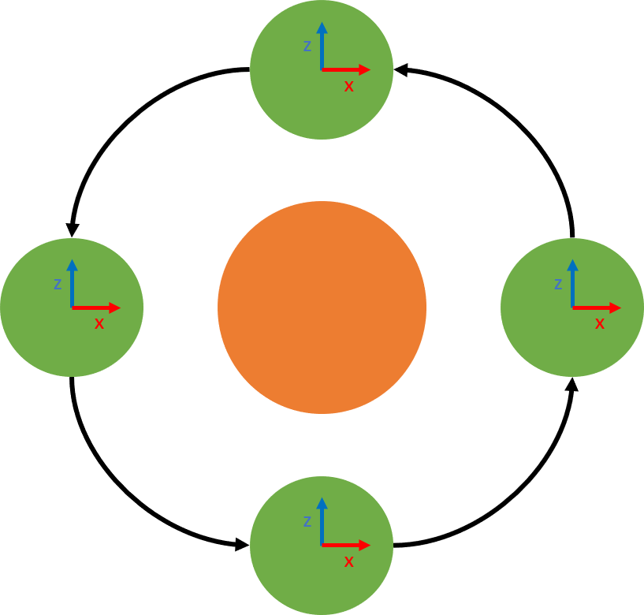

Assume that the green body has no spin. Orbiting around the orange celestrial body should not change the orientation of the green body

We have added a couple of results from the reference solution. When you switch to one of the reference results it will automatically set all the parameters for that example. If you implemented everything correctly, switching back to your own solution should not result in any visual change.

If implemented correctly, your result should look something like this:

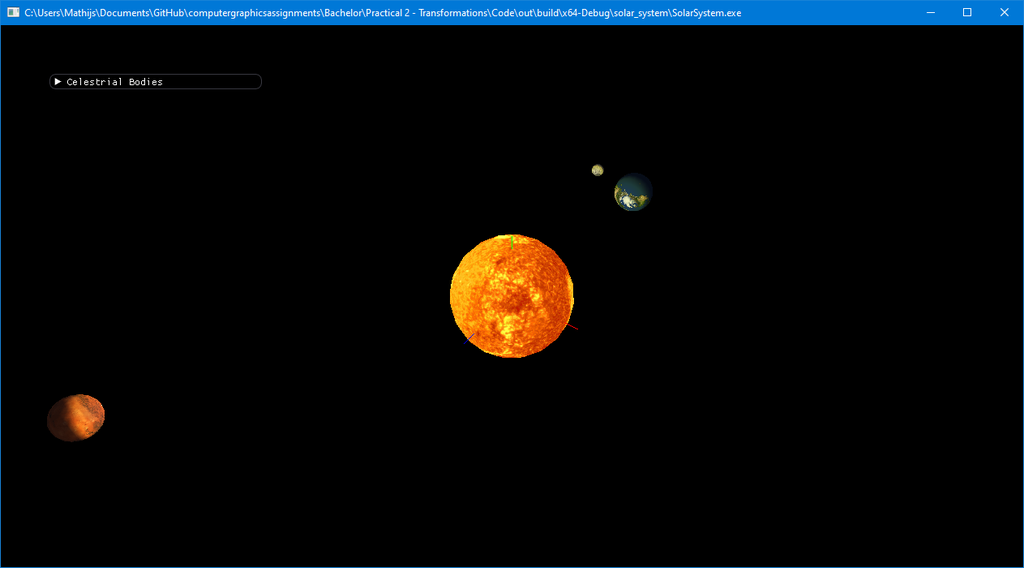

## 2. Robot Arm

In this second exercise we will model a robot arm, such as one might see in a car factory. The robot arm consists of multiple connected segments. Segment are rectangular boxes each with their own width/height/length. The back face (face with z=0) of a segment $N$ is connected to the previous segment $N-1$ front face (face with z=1) such that the centers of the faces intersect. The first box should be connected to the origin. The image below illustrates how this looks like from the side. Since this is a simple robot arm, we assume that the segments are only able to rotate around the positive x axis (`glm::vec3(1, 0, 0)`).

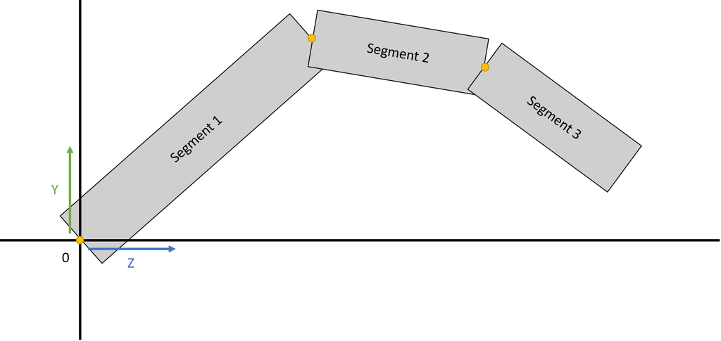

Illustration of how the robot arm should look like from the side.

Similar to the solar system exercise you are asked to implement a function that computes the transformation matrices. The input object to be transformed is a box ranging from $\vec{0}$ to $\vec{1}$. Your goal is to implement the following function in `robot_arm/src/robot_arm.cpp` such that the boxes are transformed into a robot arm.

```cpp
std::vector<glm::mat4> computeRobotArmTransforms(gsl::span<const ArmSegment> armSegments);
```

We have again included a couple of results from the reference solution which can be used to compare against.

If implemented correctly then your robot arm should look like this:

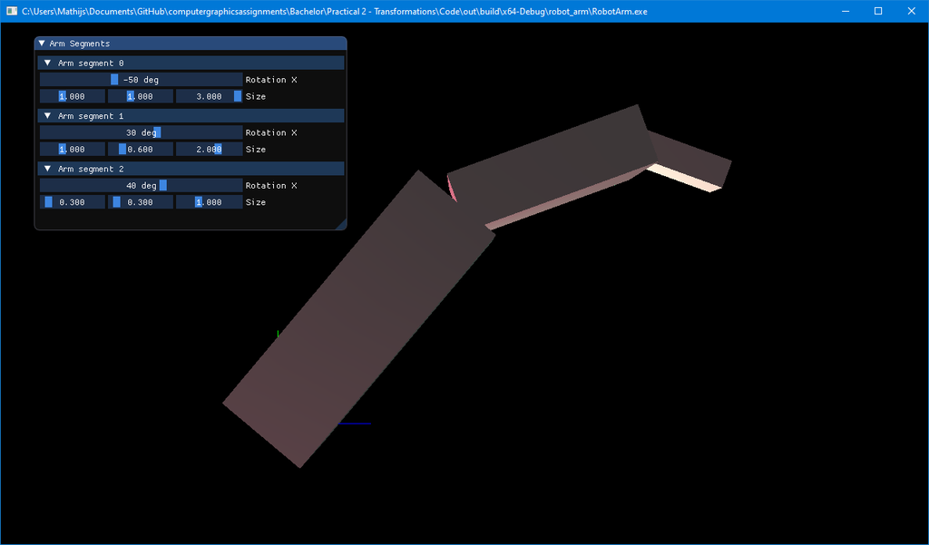

## Submission

Your hand-ins will be graded using a script. For this script to work smoothly, we ask you to only hand in *only* `robot_arm.cpp` and `solar_system.cpp`. Please **do not rename these files** and upload them directly to Brightspace (don’t put them in a zip/rar file).